# Working with databases in R

2022-09-24

## Who is Dennis Irorere?

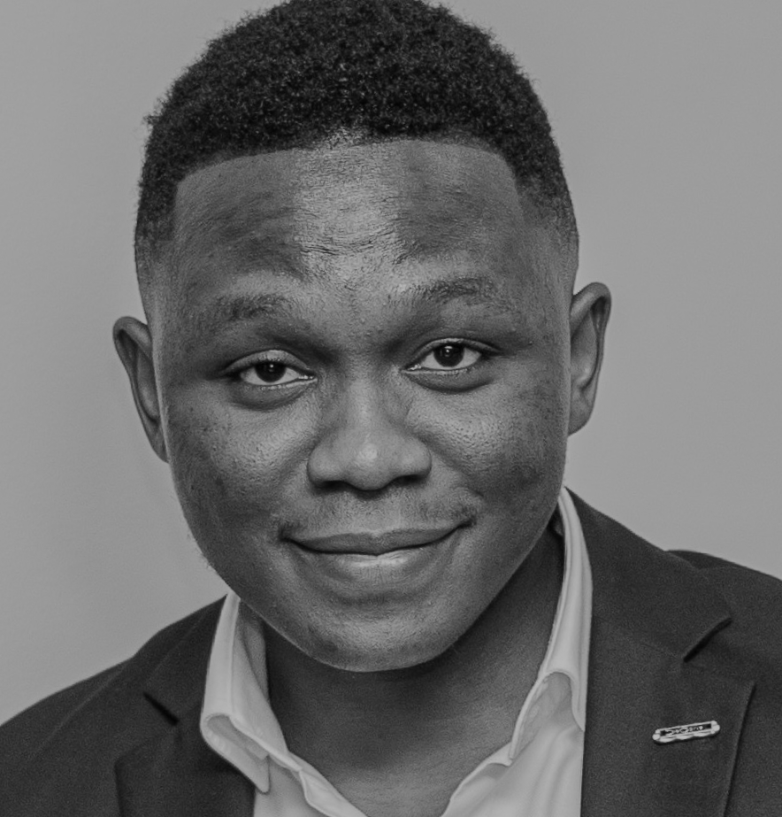

Data Scientist at Spacee,Inc

## What is a database?

[figure not shown]

## What is a database?

- A database can be defined as a collection of related data items within a specific business process or problem setting.
- A database management system (DBMS) is the software package used to define, create, use, and maintain a database

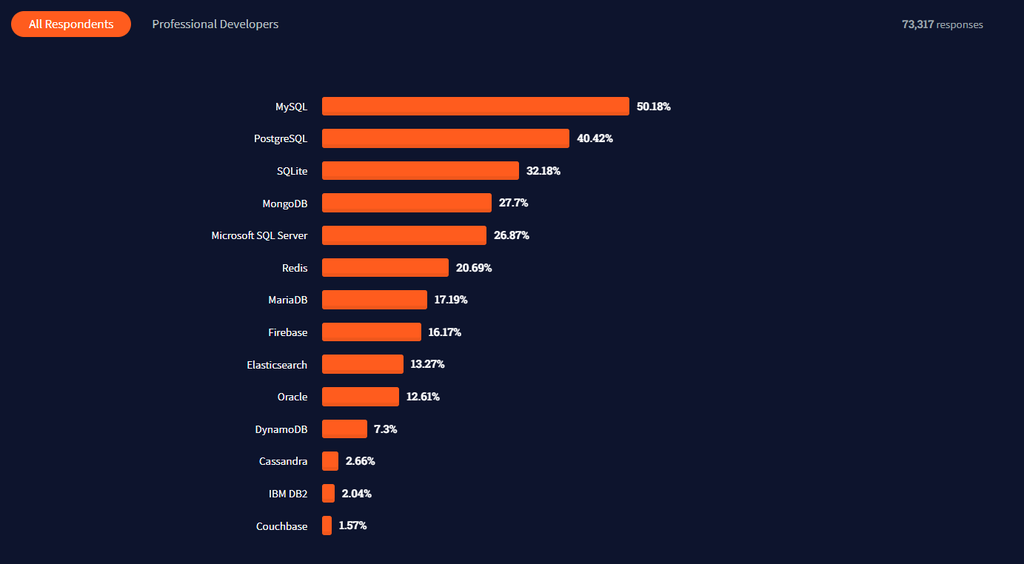

source - https://insights.stackoverflow.com/survey/2021#most-popular-technologies-database

## SQL & Relational database

- SQL - Structured Query Language, is an incredible tool for querying and managing `relational databases`.
- A relational database is a collection of information that organizes data in predefined relationships where data is stored in one or more tables of columns and rows.

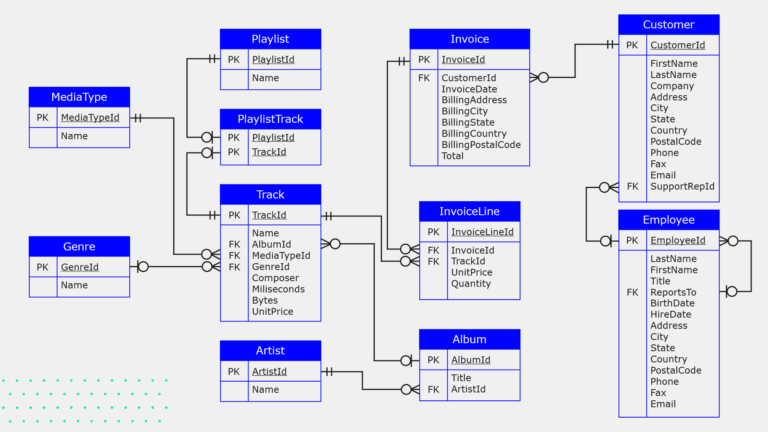

## Data created

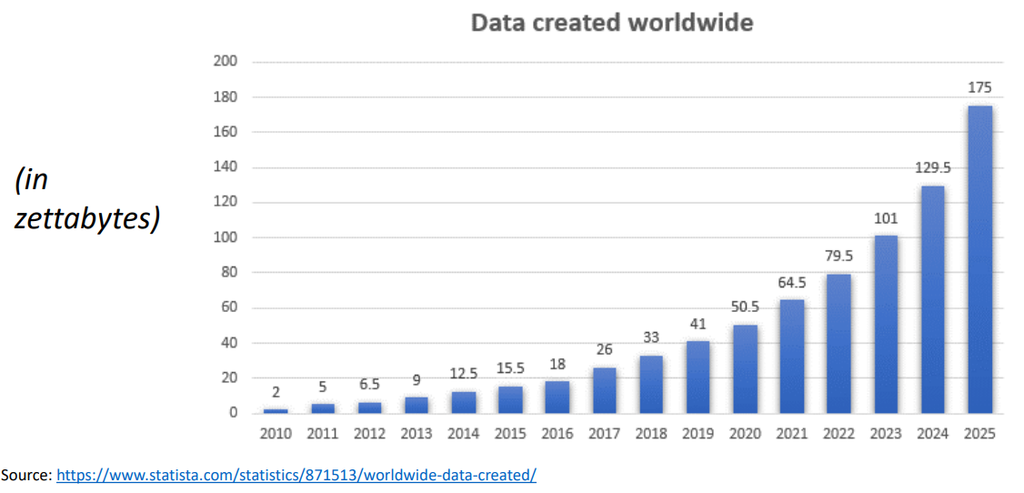

## Why do we need a Database?

- Databases can scale as your business grows
- Large volumes of data can be stored in one place
- Multiple users can read and modify the data at the same time
- Databases are searchable and sortable, so the data you need can be found quick and easily
- Databases allow you to avoid redundant information

## Who is a database users?

A database user is a person who runs applications to perform specific database operations. He/she can also directly query the database using interactive querying facilities for reporting purposes.

## Roles in Data Management

- The `information architect` (or information analyst) designs the conceptual data model
- The `database designer` translate the conceptual data model into a logical data model
- The `data owner` has the authority to ultimately decide on the acess to, and usage of, the data.
- The `database administrator` (DBA) is responsible for the implementation and monitoring of the database
- The `data analyst`, `business analyst`, and `data scientist` responsible for analyzing the data to provide new insight about customer behaviour using analytical techniques and methods

## Popular Languages for Data Science

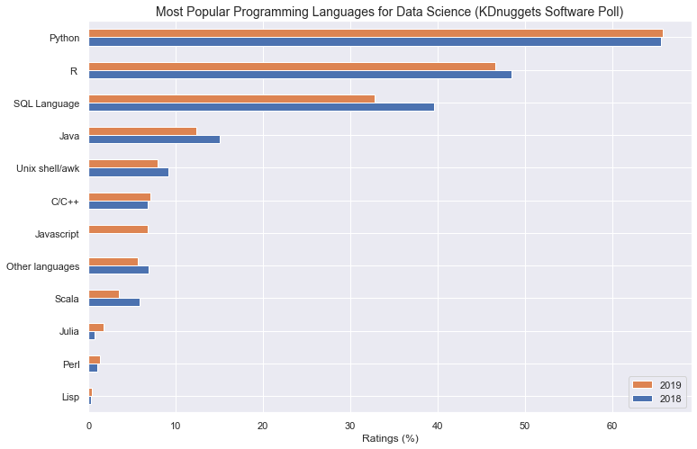

## Working with Large Datasets in R

As described by Edgar Ruiz, when connecting to a database in R there is only a “small conduit” between R and the database that often prevents us from being able to work with the data as fast as we can work with local data frames.

In order to work around this there have historically been two different options:

- The first option is to take data from the database in small chunks, save it in R memory, and then analyze it later
- A different option is to load all of the data into R

## Who has done this in the past?

[figure not shown]

source: Rstudio

## Major problem with those methods

The main problem with the methods earlier is that we are trying to perform the computations locally in R as opposed to performing computations directly on the data in the database using the SQL Engine.

Ideally, we want R to somehow send a SQL query over to the database, perform the query using the powerful SQL engine, and then have the database send back an R data frame that we can manipulate in R.

As R programmers, we of course want to write solely R code. Don’t we?

## Using dplyr to query the database

[figure not shown]

source: Rstudio

## Using dplyr to Query the Database

The `dplyr` package allows for better communications with external databases.

Enabling us to do the following:

- Push the computation to the database, allowing us to avoid bringing large amounts of data in the database into the R environment unless we specifically ask R to do it.
- We can use pipe code, which greatly enhances the readability of the code
- All the code is in R

## Let’s code

[figure not shown]

## Install and load Packages

- `dplyr` - focuses on retrieving and analyzing datasets for generating SELECT SQL Statement
- `dbplyr` - enables `dplyr` to interact with databases. It also contains the vendor-specific SQL translation
- `DBI` - Allows R send commands to database irrespective of the database management systems used
- `RSQLite` - This package allows R to interface with SQLite databases

```
install.packages(c("dplyr", "dbplyr", "DBI", "RSQLite", "dbplot", "ggplot2"))
```

```r
library(DBI)
library(dplyr)
library(dbplyr)
```

## Download Chinook database and Connect to the database

```
setwd("C:/Users/Dee/root/Projects/basic_projects/Hands_on-DataScience/databases-R")
url <-  'https://www.sqlitetutorial.net/wp-content/uploads/2018/03/chinook.zip'
download.file(url, "chinook.zip")
unzip("chinook.zip")
```

```r
chinook <- dbConnect(RSQLite::SQLite(), "chinook.db")
```

This command creates a reference to the database, and tells R to connect to this database in a specific location.

## Inspect the chinook database

```r
src_dbi(chinook)
```

```
## src:  sqlite 3.39.3 [C:\Users\Dee\root\Projects\basic_projects\Hands_on-DataScience\databases-R\chinook.db]
## tbls: albums, artists, customers, employees, genres, invoice_items, invoices,
##   media_types, playlist_track, playlists, sqlite_sequence, sqlite_stat1, tracks
```

The above function display the location of the database, as well as the tables contained in the database. This database consist of tables such as `albums`, `artists`, `customers`, `employees`, `genres`, `invoice_items`, `invoices`, `media_types`, `tracks`, `playlists`, `playlist_track`

Now that we know we can connect to the database, let’s explore how to query the data from a specific table into R

## Querying the database with SQL Syntax

To connect to tables within a database, you can use the `tbl()` function from `dplyr`. This function can be used to send SQL queries to the database.

```r
tbl(chinook, sql("SELECT * FROM employees LIMIT 100"))
```

```
## # Source:   SQL [8 x 15]
## # Database: sqlite 3.39.3 [C:\Users\Dee\root\Projects\basic_projects\Hands_on-DataScience\databases-R\chinook.db]
##   EmployeeId LastName FirstName Title ReportsTo BirthDate HireDate Address City
##        <int> <chr>    <chr>     <chr>     <int> <chr>     <chr>    <chr>   <chr>
## 1          1 Adams    Andrew    Gene…        NA 1962-02-… 2002-08… 11120 … Edmo…
## 2          2 Edwards  Nancy     Sale…         1 1958-12-… 2002-05… 825 8 … Calg…
## 3          3 Peacock  Jane      Sale…         2 1973-08-… 2002-04… 1111 6… Calg…
## 4          4 Park     Margaret  Sale…         2 1947-09-… 2003-05… 683 10… Calg…
## 5          5 Johnson  Steve     Sale…         2 1965-03-… 2003-10… 7727B … Calg…
## 6          6 Mitchell Michael   IT M…         1 1973-07-… 2003-10… 5827 B… Calg…
## 7          7 King     Robert    IT S…         6 1970-05-… 2004-01… 590 Co… Leth…
## 8          8 Callahan Laura     IT S…         6 1968-01-… 2004-03… 923 7 … Leth…
## # … with 6 more variables: State <chr>, Country <chr>, PostalCode <chr>,
## #   Phone <chr>, Fax <chr>, Email <chr>
```

With this approach you can use SQL queries if you are comfortable with SQL

## Querying the database with dplyr Syntax

One of the strengths of `dplyr` is that the same operation can be done using `dplyr`’s verbs instead of writing SQL. First, we select the table on which to do the operations by creating the `employee` object, and then we use the standard `dplyr` syntax as if it were a data frame.

```r
employees <- tbl(chinook, "employees")
employees %>%
  select(EmployeeId, LastName, FirstName, Title, ReportsTo, Phone, Email)
```

```
## # Source:   SQL [8 x 7]
## # Database: sqlite 3.39.3 [C:\Users\Dee\root\Projects\basic_projects\Hands_on-DataScience\databases-R\chinook.db]
##   EmployeeId LastName FirstName Title               ReportsTo Phone        Email
##        <int> <chr>    <chr>     <chr>                   <int> <chr>        <chr>
## 1          1 Adams    Andrew    General Manager            NA +1 (780) 42… andr…
## 2          2 Edwards  Nancy     Sales Manager               1 +1 (403) 26… nanc…
## 3          3 Peacock  Jane      Sales Support Agent         2 +1 (403) 26… jane…
## 4          4 Park     Margaret  Sales Support Agent         2 +1 (403) 26… marg…
## 5          5 Johnson  Steve     Sales Support Agent         2 1 (780) 836… stev…
## 6          6 Mitchell Michael   IT Manager                  1 +1 (403) 24… mich…
## 7          7 King     Robert    IT Staff                    6 +1 (403) 45… robe…
## 8          8 Callahan Laura     IT Staff                    6 +1 (403) 46… laur…
```

In this case, the `employees` object behaves like a data frame. Several functions that can be used with the data frames can also be used on tables from a database.

## Lets use familiar `dplyr` commands to query the database

```
head(employees, n = 8)
```

```r
employees %>%
  select(LastName, FirstName, Title, ReportsTo, Phone) %>%
  arrange(LastName)
```

```
## # Source:     SQL [8 x 5]
## # Database:   sqlite 3.39.3 [C:\Users\Dee\root\Projects\basic_projects\Hands_on-DataScience\databases-R\chinook.db]
## # Ordered by: LastName
##   LastName FirstName Title               ReportsTo Phone
##   <chr>    <chr>     <chr>                   <int> <chr>
## 1 Adams    Andrew    General Manager            NA +1 (780) 428-9482
## 2 Callahan Laura     IT Staff                    6 +1 (403) 467-3351
## 3 Edwards  Nancy     Sales Manager               1 +1 (403) 262-3443
## 4 Johnson  Steve     Sales Support Agent         2 1 (780) 836-9987
## 5 King     Robert    IT Staff                    6 +1 (403) 456-9986
## 6 Mitchell Michael   IT Manager                  1 +1 (403) 246-9887
## 7 Park     Margaret  Sales Support Agent         2 +1 (403) 263-4423
## 8 Peacock  Jane      Sales Support Agent         2 +1 (403) 262-3443
```

## `dplyr` filter and arrange function

```r
employees %>%
  filter(Title == "Sales Support Agent") %>%
  select(LastName, FirstName, Address) %>%
  arrange(LastName)
```

```
## # Source:     SQL [3 x 3]
## # Database:   sqlite 3.39.3 [C:\Users\Dee\root\Projects\basic_projects\Hands_on-DataScience\databases-R\chinook.db]
## # Ordered by: LastName
##   LastName FirstName Address
##   <chr>    <chr>     <chr>
## 1 Johnson  Steve     7727B 41 Ave
## 2 Park     Margaret  683 10 Street SW
## 3 Peacock  Jane      1111 6 Ave SW
```

## `dplyr` group_by and summarize functions

```r
employees %>%
  group_by(ReportsTo) %>%
  summarize(numberAtLocation = n())
```

```
## # Source:   SQL [4 x 2]
## # Database: sqlite 3.39.3 [C:\Users\Dee\root\Projects\basic_projects\Hands_on-DataScience\databases-R\chinook.db]
##   ReportsTo numberAtLocation
##       <int>            <int>
## 1        NA                1
## 2         1                2
## 3         2                3
## 4         6                2
```

## SQL translation

Relational databases typically use a special-purpose language, Structured Query Language (SQL), to manage and query data.

```
SELECT
  *
FROM
  employees
LIMIT
  10
```

Behind the scenes, dplyr:

- translates your R code into SQL
- submits it to the database
- translates the database’s response into an R data frame

## Lets look under the hood of the dplyr’s code

```r
show_query(head(employees, n = 10))
```

```
## <SQL>
## SELECT *
## FROM `employees`
## LIMIT 10
```

The output shows the actual SQL query sent to the database; it matches our manually constructed SELECT statement above.

Instead of having to formulate the SQL query ourselves - and having to mentally switch back and forth between R and SQL syntax - we can delegate this translation to dplyr. (You don’t even need to know SQL to interact with a database via dplyr!)

## Laziness

Hadley Wickham, the author of dplyr explains:

When working with databases, dplyr tries to be as lazy as possible:

- It never pulls data into R unless you explicitly ask for it.
- It delays doing any work until the last possible moment
- It collects together everything you want to do and then sends it to the database in one step

When you construct a `dplyr` query, you can connect multiple verbs into a single pipeline. For example, we combined the filter() and select() verbs using the %>% pipe.

## More example of `dplyr` in action

```r
salesSupportAgents <- employees %>%
  filter(Title == "Sales Support Agent") %>%
  select(LastName, FirstName, Address) %>%
  arrange(LastName) %>%
  collect()
salesSupportAgents
```

```
## # A tibble: 3 × 3
##   LastName FirstName Address
##   <chr>    <chr>     <chr>
## 1 Johnson  Steve     7727B 41 Ave
## 2 Park     Margaret  683 10 Street SW
## 3 Peacock  Jane      1111 6 Ave SW
```

As we’ve seen, for simple tasks, and even many complex tasks, dplyr syntax can be used to query external databases.

## Using dbplot for visualization

We can use the same chinook database from SQLite we were using above. Suppose we desire to see how many types of each employee there are in the database. We can produce a barplot to show this.

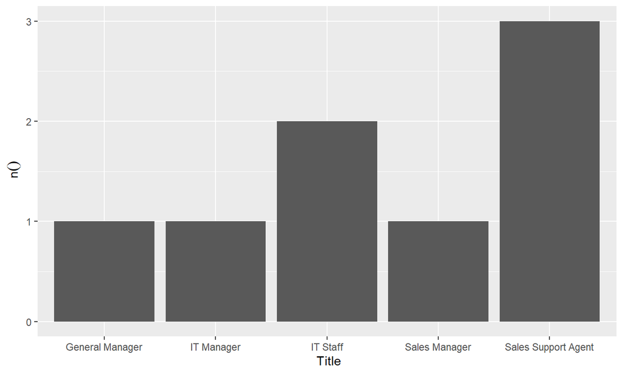

## Customized dbplot

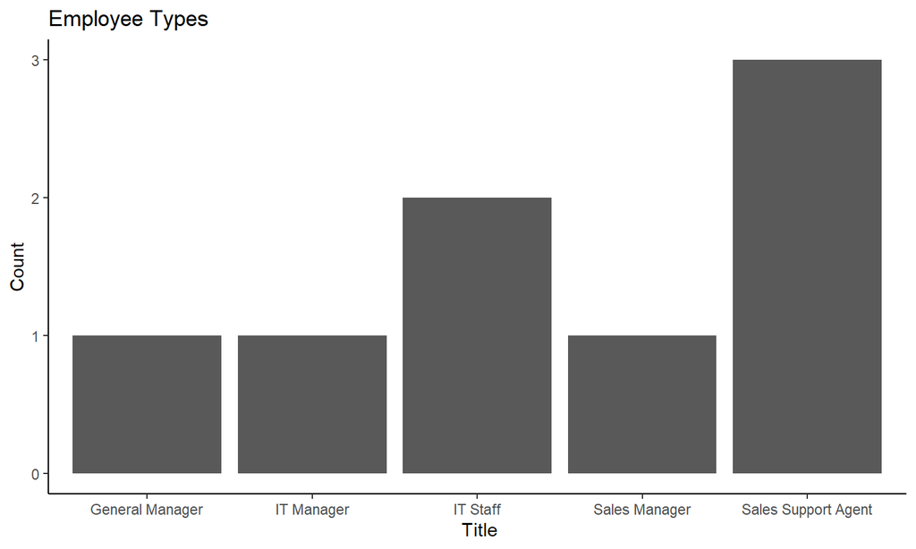

```r
library(ggplot2)
employees %>%
  dbplot_bar(Title) +
  labs(title = "Employee Types") +
  ylab("Count") +
  theme_classic()
```

## Any Questions?

[figure not shown]

## References

- https://www.jeffdoser.com/files/for875/_book/databases-and-r.html
- https://rviews.rstudio.com/2017/05/17/databases-using-r/
- https://datacarpentry.org/R-ecology-lesson/05-r-and-databases.html

## Until Next time

[figure not shown]